# 楊子萱_110700049_hw08

楊子萱

2023-11-19

# Introduction

In order to conduct text mining, I decided to use the dataset about **Sleep efficiency**. Even though this dataset **doesn’t contain variables, whose values are sentences**, I would like to use text mining to evaluate the variables in the **date and time format**. The text mining techniques I will be using are listed below. To prevent the problem of **over-fitting**, I will split the data into **training** set, **validation** set, and **test** set. Last but not least, I will be discussing some possible problems for future studies.

# Text Mining Techniques

```
1. Text Data Preprocessing

  a. Tokenization

  b. Feature Engineering

2. Frequency Analysis

  a. Frequency Table

  b. Bar Plot

  c. Pie Chart

  d. Word Cloud
```

# Classification Techniques

```
1. Naive Bayes

2. Multinomial Logistic Regression

3. Random Forest
```

# Data Preprocessing

## Check Type & Structure of Data

```r
data = read.csv(file = 'Sleep_Efficiency.csv', header = TRUE, sep = ',')
class(data)
```

```
## [1] "data.frame"
```

```r
str(data)
```

```
## 'data.frame':    452 obs. of  15 variables:
##  $ ID                    : int  1 2 3 4 5 6 7 8 9 10 ...
##  $ Age                   : int  65 69 40 40 57 36 27 53 41 11 ...
##  $ Gender                : chr  "Female" "Male" "Female" "Female" ...
##  $ Bedtime               : chr  "2021-03-06 01:00:00" "2021-12-05 02:00:00" "2021-05-25 21:30:00" "2021-11-03 02:30:00" ...
##  $ Wakeup.time           : chr  "2021-03-06 07:00:00" "2021-12-05 09:00:00" "2021-05-25 05:30:00" "2021-11-03 08:30:00" ...
##  $ Sleep.duration        : num  6 7 8 6 8 7.5 6 10 6 9 ...
##  $ Sleep.efficiency      : num  0.88 0.66 0.89 0.51 0.76 0.9 0.54 0.9 0.79 0.55 ...
##  $ REM.sleep.percentage  : int  18 19 20 23 27 23 28 28 28 18 ...
##  $ Deep.sleep.percentage : int  70 28 70 25 55 60 25 52 55 37 ...
##  $ Light.sleep.percentage: int  12 53 10 52 18 17 47 20 17 45 ...
##  $ Awakenings            : num  0 3 1 3 3 0 2 0 3 4 ...
##  $ Caffeine.consumption  : num  0 0 0 50 0 NA 50 50 50 0 ...
##  $ Alcohol.consumption   : num  0 3 0 5 3 0 0 0 0 0 ...
##  $ Smoking.status        : chr  "Yes" "Yes" "No" "Yes" ...
##  $ Exercise.frequency    : num  3 3 3 1 3 1 1 3 1 0 ...
```

## Check For Missing Data

```r
cat("Number of rows with missing values:", sum(!complete.cases(data)), "\n")
```

```
## Number of rows with missing values: 64
```

```r
missing_counts <- colSums(is.na(data))
columns_with_missing <- sum(missing_counts > 0)
cat("Number of columns with missing values:", columns_with_missing, "\n")
```

```
## Number of columns with missing values: 4
```

```r
if (columns_with_missing > 0) {
  cat("Columns with missing values:", paste(names(missing_counts[missing_counts > 0]), collapse = ", "), "\n")

  cat("Number of missing values for each variable:\n")
  for (col in names(missing_counts[missing_counts > 0])) {
    cat(col, ":", missing_counts[col], "\n")
  }
}
```

```
## Columns with missing values: Awakenings, Caffeine.consumption, Alcohol.consumption, Exercise.frequency
## Number of missing values for each variable:
## Awakenings : 20
## Caffeine.consumption : 25
## Alcohol.consumption : 14
## Exercise.frequency : 6
```

## Check For Unique Values

```r
unique_values <- lapply(data, unique)

for (i in seq_along(unique_values)) {
  cat("Variable:", names(unique_values)[i], "\n")
  print(unique_values[[i]])
  cat("\n")
}
```

[output not shown]

[output cut: 346 more lines]

## Bucketing

```r
data$Sleep.efficiency.range <- cut(data$Sleep.efficiency,
                                   breaks = c(0.5, 0.6, 0.7, 0.8, 0.9, 1.0),
                                   labels = c("0.5~0.59", "0.6~0.69", "0.7~0.79", "0.8~0.89", "0.9~0.99"),
                                   include.lowest = TRUE)

table(data$Sleep.efficiency.range)
```

```
##
## 0.5~0.59 0.6~0.69 0.7~0.79 0.8~0.89 0.9~0.99
##       61       55       90      140      106
```

## Summary of Correlation

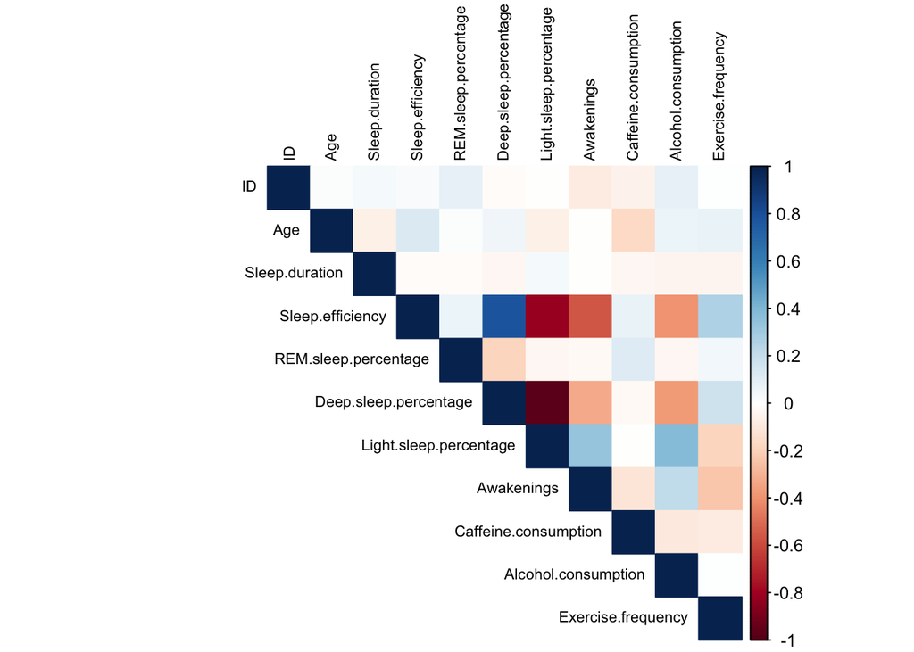

```r
library(corrplot)
num_col <- sapply(data, function(x) is.numeric(x))
num <- data[, num_col]

correlation_matrix <- cor(num, use = "complete.obs")

corrplot(correlation_matrix,
         method = "color",
         type = "upper",
         tl.cex = 0.7,
         tl.col = "black"
)
```

## Handling Missing Data

### Awakenings

#### Distribution

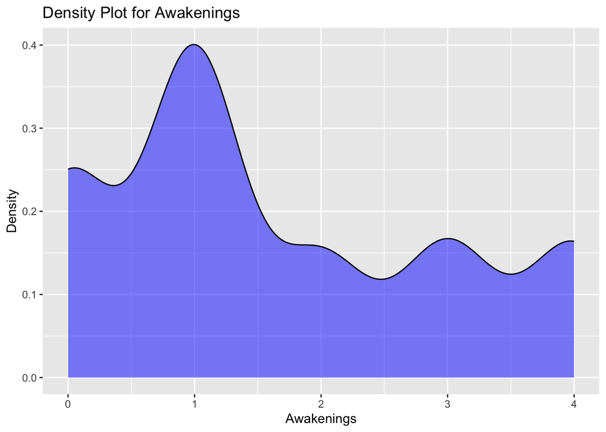

```r
library(ggplot2)

ggplot(data, aes(x = Awakenings)) +
  geom_density(fill = "blue", alpha = 0.5) +
  labs(title = "Density Plot for Awakenings", x = "Awakenings", y = "Density")
```

#### Mean Imputation

```r
library(Hmisc)
mean <- mean(data$Awakenings, na.rm = TRUE)

cat("Mean:", mean, "\n")
```

```
## Mean: 1.641204
```

```r
data$Awakenings <- impute(data$Awakenings, fun = mean)
```

### Caffeine.consumption

#### Distribution

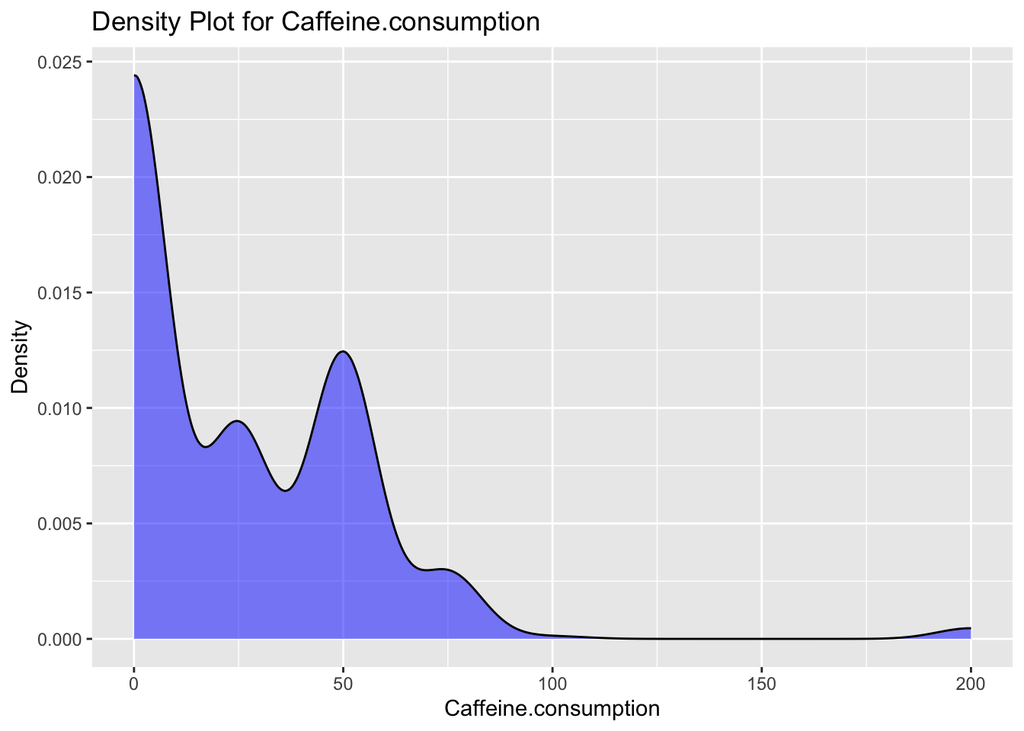

```r
ggplot(data, aes(x = Caffeine.consumption)) +
  geom_density(fill = "blue", alpha = 0.5) +
  labs(title = "Density Plot for Caffeine.consumption", x = "Caffeine.consumption", y = "Density")
```

#### Mean Imputation

```r
mean <- mean(data$Caffeine.consumption, na.rm = TRUE)

cat("Mean:", round(mean), "\n")
```

```
## Mean: 24
```

```r
data$Caffeine.consumption <- impute(data$Caffeine.consumption, fun = round(mean))
```

### Alcohol.consumption

#### Distribution

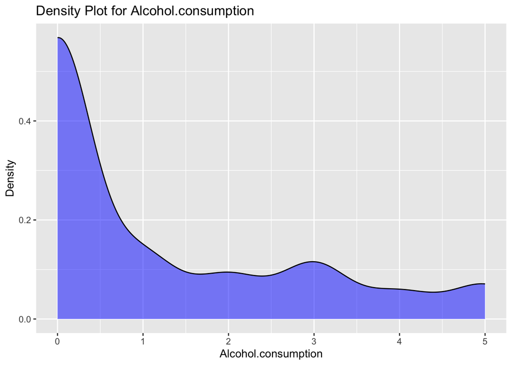

```r
ggplot(data, aes(x = Alcohol.consumption)) +
  geom_density(fill = "blue", alpha = 0.5) +
  labs(title = "Density Plot for Alcohol.consumption", x = "Alcohol.consumption", y = "Density")
```

#### Mean Imputation

```r
mean <- mean(data$Alcohol.consumption, na.rm = TRUE)

cat("Mean:", round(mean), "\n")
```

```
## Mean: 1
```

```r
data$Alcohol.consumption <- impute(data$Alcohol.consumption, fun = round(mean))
```

### Exercise.frequency

#### Distribution

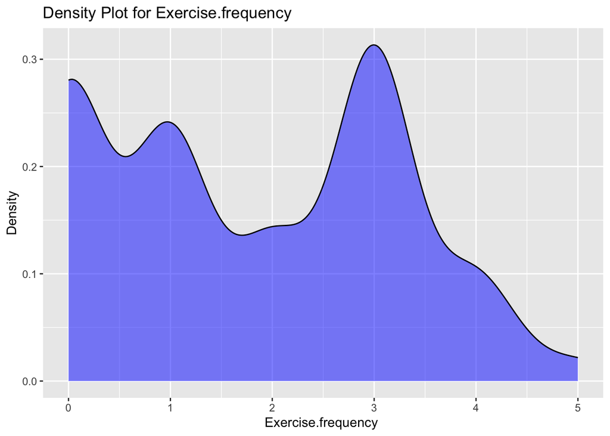

```r
ggplot(data, aes(x = Exercise.frequency )) +
  geom_density(fill = "blue", alpha = 0.5) +
  labs(title = "Density Plot for Exercise.frequency ", x = "Exercise.frequency ", y = "Density")
```

#### Mean Imputation

```r
mean <- mean(data$Exercise.frequency, na.rm = TRUE)

cat("Mean:", round(mean), "\n")
```

```
## Mean: 2
```

```r
data$Exercise.frequency <- impute(data$Exercise.frequency, fun = round(mean))
```

## Text Data Preprocessing

### a. Tokenization

#### Bedtime

```r
bedtime_values <- data$Bedtime

tokenized_bedtime <- strsplit(bedtime_values, " ")
max_elements <- max(sapply(tokenized_bedtime, length))
padded_tokenized_bedtime <- lapply(tokenized_bedtime, function(x) c(x, rep(NA, max_elements - length(x))))

tokenized_bedtime <- data.frame(do.call(rbind, padded_tokenized_bedtime))
colnames(tokenized_bedtime) <- c("b_Y/M/D", "b_time", rep("", max_elements - 2))

data <- cbind(data, tokenized_bedtime)

print(head(tokenized_bedtime))
```

```
##      b_Y/M/D   b_time
## 1 2021-03-06 01:00:00
## 2 2021-12-05 02:00:00
## 3 2021-05-25 21:30:00
## 4 2021-11-03 02:30:00
## 5 2021-03-13 01:00:00
## 6 2021-07-01 21:00:00
```

#### Wakeup.time

```r
waketime_values <- data$Wakeup.time

tokenized_waketime <- strsplit(waketime_values, " ")
max_elements <- max(sapply(tokenized_waketime, length))
padded_tokenized_waketime <- lapply(tokenized_waketime, function(x) c(x, rep(NA, max_elements - length(x))))

tokenized_waketime <- data.frame(do.call(rbind, padded_tokenized_waketime))
colnames(tokenized_waketime) <- c("w_Y/M/D", "w_time", rep("", max_elements - 2))

data <- cbind(data, tokenized_waketime)

print(head(tokenized_waketime))
```

```
##      w_Y/M/D   w_time
## 1 2021-03-06 07:00:00
## 2 2021-12-05 09:00:00
## 3 2021-05-25 05:30:00
## 4 2021-11-03 08:30:00
## 5 2021-03-13 09:00:00
## 6 2021-07-01 04:30:00
```

The original data format of “Bedtime” and “Wakeup.time” look something like this “2021-03-06 01:00:00”. Thus, I used tokenization to separate the year/month/date and the time.

### b. Feature Engineering

#### Bedtime

```r
data$Bedtime <- as.POSIXct(data$Bedtime, format="%Y-%m-%d %H:%M:%S")

data$b_day_of_week <- weekdays(data$Bedtime)
data$b_weekend <- ifelse(weekdays(data$Bedtime) %in% c("Saturday", "Sunday"), 1, 0)

print(head(data[, c("Bedtime", "b_day_of_week", "b_weekend")]))
```

```
##               Bedtime b_day_of_week b_weekend
## 1 2021-03-06 01:00:00      Saturday         1
## 2 2021-12-05 02:00:00        Sunday         1
## 3 2021-05-25 21:30:00       Tuesday         0
## 4 2021-11-03 02:30:00     Wednesday         0
## 5 2021-03-13 01:00:00      Saturday         1
## 6 2021-07-01 21:00:00      Thursday         0
```

#### Wakeup.time

```r
data$Wakeup.time <- as.POSIXct(data$Wakeup.time, format="%Y-%m-%d %H:%M:%S")

data$w_day_of_week <- weekdays(data$Wakeup.time)
data$w_weekend <- ifelse(weekdays(data$Wakeup.time) %in% c("Saturday", "Sunday"), 1, 0)

print(head(data[, c("Wakeup.time", "w_day_of_week", "w_weekend")]))
```

```
##           Wakeup.time w_day_of_week w_weekend
## 1 2021-03-06 07:00:00      Saturday         1
## 2 2021-12-05 09:00:00        Sunday         1
## 3 2021-05-25 05:30:00       Tuesday         0
## 4 2021-11-03 08:30:00     Wednesday         0
## 5 2021-03-13 09:00:00      Saturday         1
## 6 2021-07-01 04:30:00      Thursday         0
```

I realized that by performing feature engineering, I could extract extra features such as the day of week and whether the date is a weekday or weekend.

# Frequency Analysis

## 1-1. Bedtime

### a. Frequency Table

```r
freq_table <- summary(factor(data$b_time))
freq_table_df <- as.data.frame(freq_table)
print(freq_table_df)
```

```
##          freq_table
## 00:00:00         75
## 00:30:00         35
## 01:00:00         35
## 01:30:00         32
## 02:00:00         32
## 02:30:00         32
## 21:00:00         38
## 21:30:00         35
## 22:00:00         56
## 22:30:00         27
## 23:00:00         55
```

### b. Bar Plot

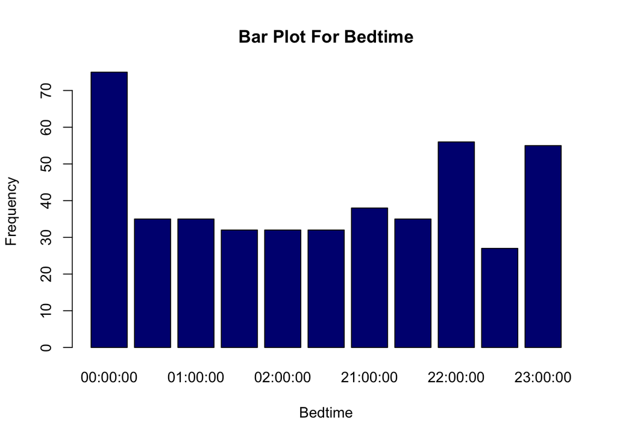

```r
barplot(table(data$b_time), main = "Bar Plot For Bedtime", xlab = "Bedtime", ylab = "Frequency", col = "navy")
```

### c. Pie Chart

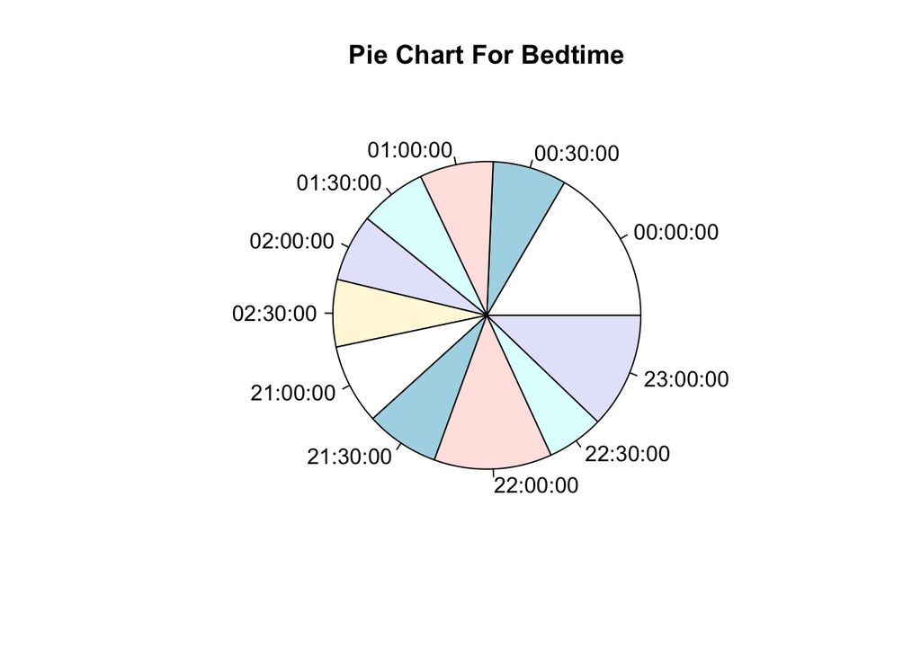

```r
pie(table(data$b_time), main = "Pie Chart For Bedtime")
```

### d. Word Cloud

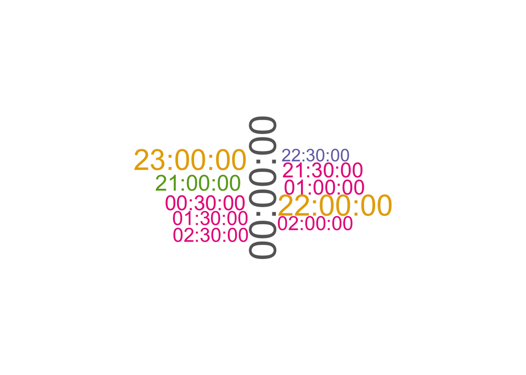

```r
library(wordcloud)
data$b_time <- as.character(data$b_time)

time_descriptions <- data$b_time
words <- unlist(strsplit(time_descriptions, "\\s+"))
word_freqs <- table(words)
word_freq_df <- data.frame(word = names(word_freqs), freq = as.numeric(word_freqs))

if (nrow(word_freq_df) > 0) {
  wordcloud(
    words = word_freq_df$word,
    freq = word_freq_df$freq,
    min.freq = 1,
    scale = c(3, 0.5),
    colors = brewer.pal(8, "Dark2"),
    random.order = FALSE,
    rot.per = 0.15,
    use.r.layout = FALSE
  )
} else {
  cat("Error: No data available for word cloud.\n")
}
```

## 1-2. b_day_of_week

### a. Frequency Table

```r
freq_table <- summary(factor(data$b_day_of_week))
freq_table_df <- as.data.frame(freq_table)
print(freq_table_df)
```

```
##           freq_table
## Friday            71
## Monday            59
## Saturday          74
## Sunday            57
## Thursday          62
## Tuesday           57
## Wednesday         72
```

### b. Bar Plot

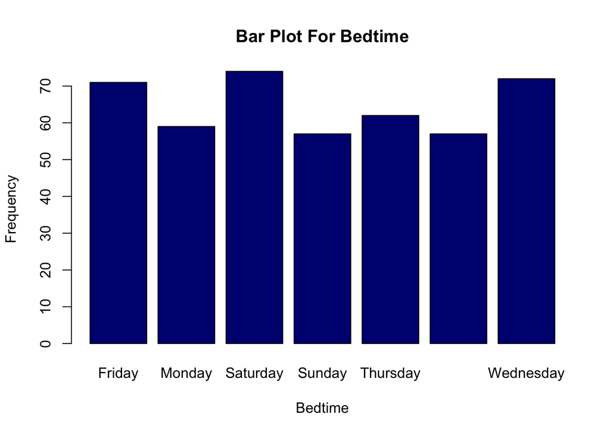

```r
barplot(table(data$b_day_of_week), main = "Bar Plot For Bedtime", xlab = "Bedtime", ylab = "Frequency", col = "navy")
```

### c. Pie Chart

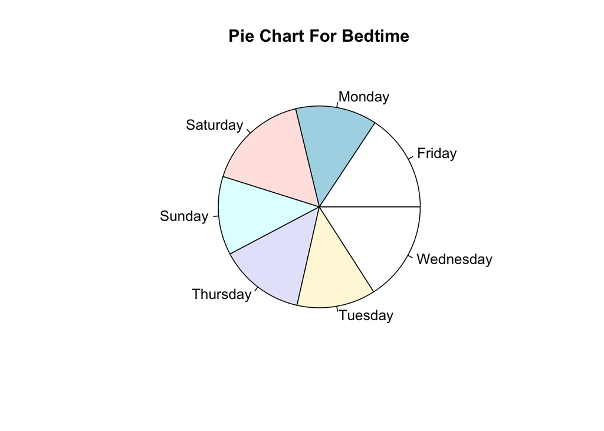

```r
pie(table(data$b_day_of_week), main = "Pie Chart For Bedtime")
```

### d. Word Cloud

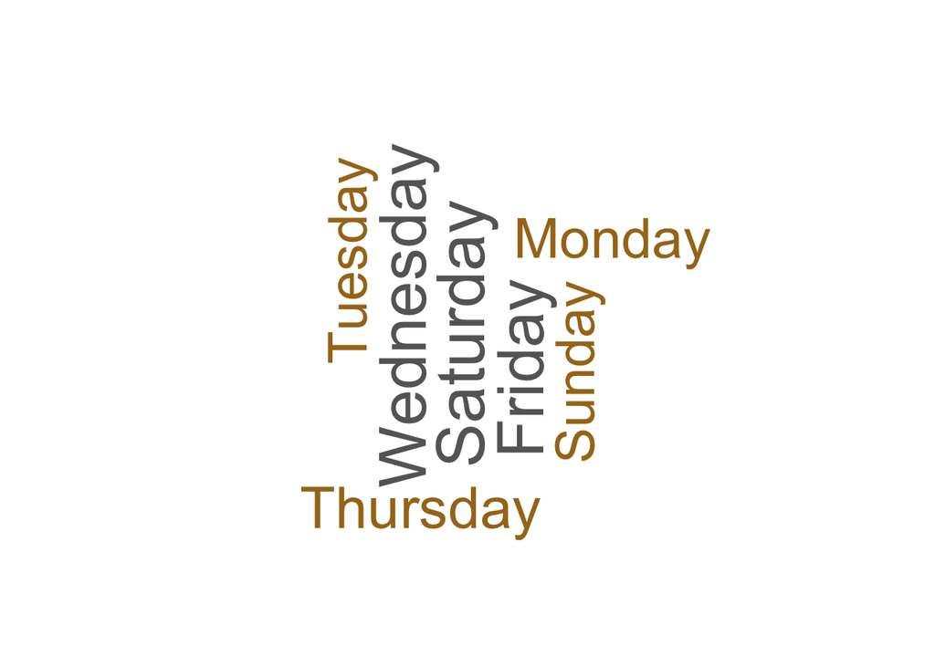

```r
data$b_day_of_week <- as.character(data$b_day_of_week)

time_descriptions <- data$b_day_of_week
words <- unlist(strsplit(time_descriptions, "\\s+"))
word_freqs <- table(words)
word_freq_df <- data.frame(word = names(word_freqs), freq = as.numeric(word_freqs))

if (nrow(word_freq_df) > 0) {
  wordcloud(
    words = word_freq_df$word,
    freq = word_freq_df$freq,
    min.freq = 1,
    scale = c(3, 0.5),
    colors = brewer.pal(8, "Dark2"),
    random.order = FALSE,
    rot.per = 0.8,
    use.r.layout = FALSE
  )
} else {
  cat("Error: No data available for word cloud.\n")
}
```

## 1-3. b_weekend

### a. Frequency Table

```r
freq_table <- summary(factor(data$b_weekend))
freq_table_df <- as.data.frame(freq_table)
print(freq_table_df)
```

```
##   freq_table
## 0        321
## 1        131
```

### b. Bar Plot

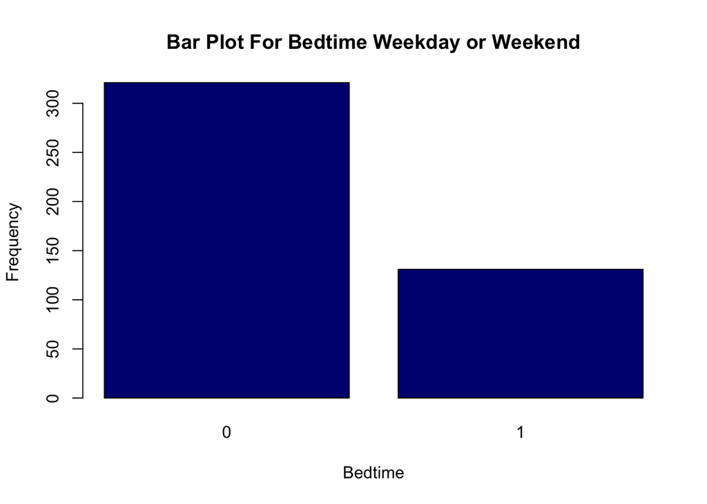

```r
barplot(table(data$b_weekend), main = "Bar Plot For Bedtime Weekday or Weekend", xlab = "Bedtime", ylab = "Frequency", col = "navy")
```

### c. Pie Chart

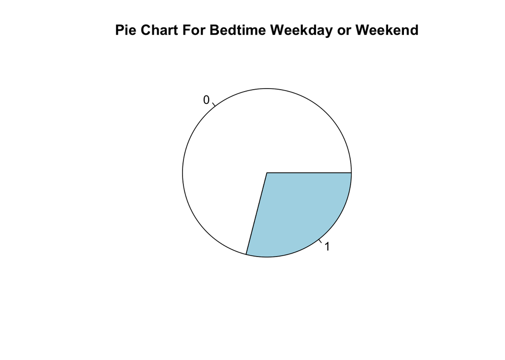

```r
pie(table(data$b_weekend), main = "Pie Chart For Bedtime Weekday or Weekend")
```

## 2. Waketime

### a. Frequency Table

```r
freq_table <- summary(factor(data$w_time))
freq_table_df <- as.data.frame(freq_table)
print(freq_table_df)
```

```
##          freq_table
## 03:00:00          7
## 03:30:00          3
## 04:00:00         19
## 04:30:00         24
## 05:00:00         46
## 05:30:00         34
## 06:00:00         35
## 06:30:00         29
## 07:00:00         46
## 07:30:00         32
## 08:00:00         35
## 08:30:00         25
## 09:00:00         49
## 09:30:00         25
## 10:00:00         27
## 10:30:00          8
## 11:00:00          4
## 11:30:00          2
## 12:30:00          2
```

### b. Bar Plot

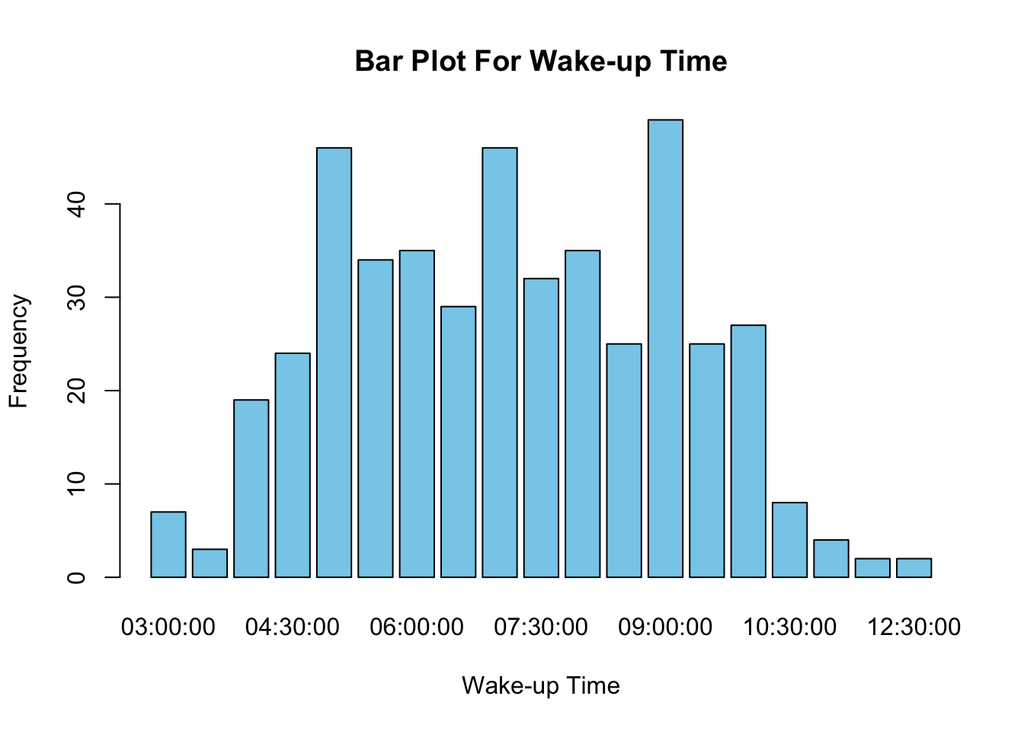

```r
barplot(table(data$w_time), main = "Bar Plot For Wake-up Time", xlab = "Wake-up Time", ylab = "Frequency", col = "skyblue")
```

### c. Pie Chart

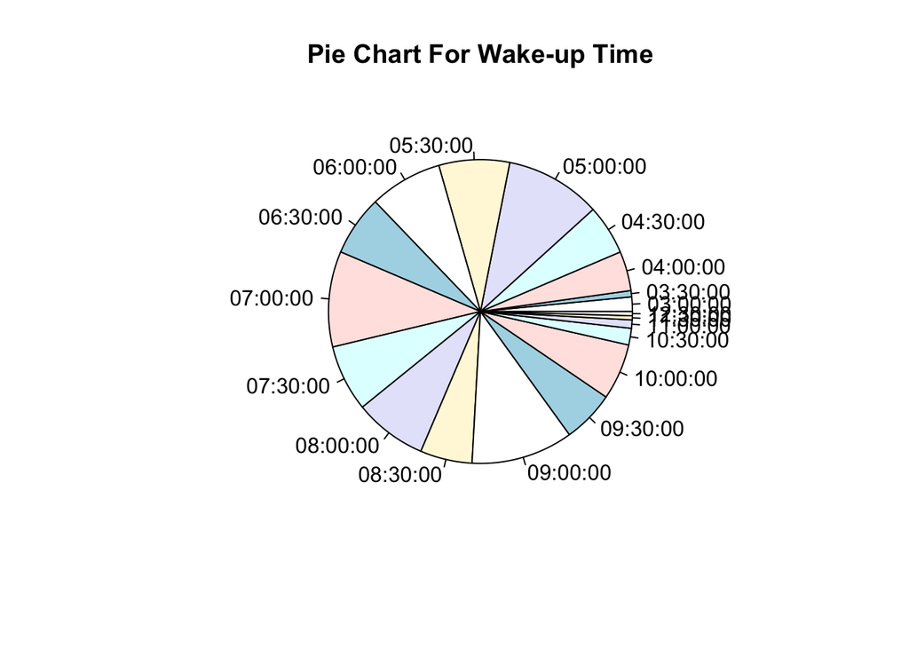

```r
pie(table(data$w_time), main = "Pie Chart For Wake-up Time")
```

### d. Word Cloud

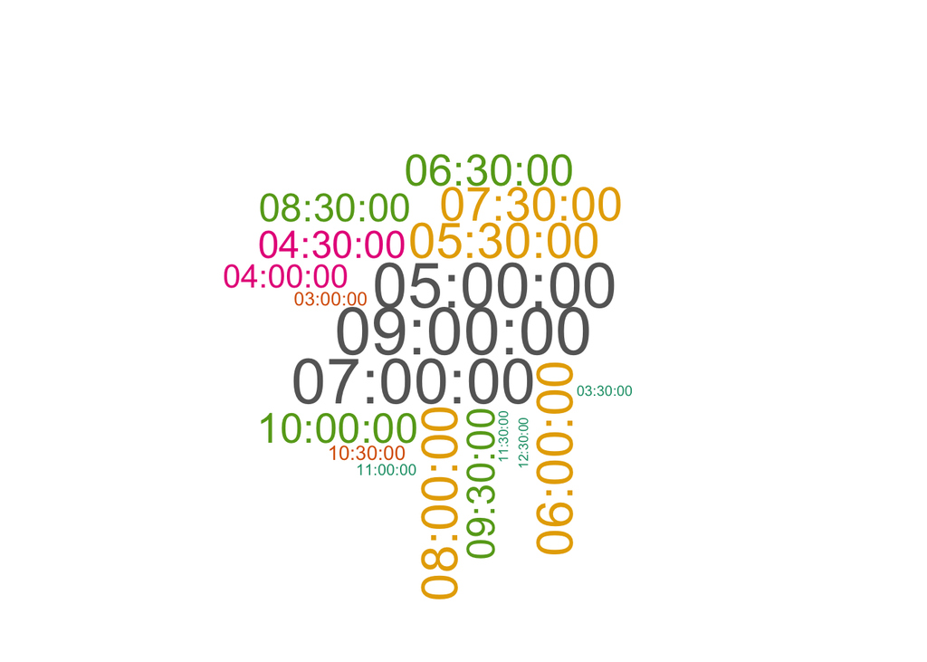

```r
data$w_time <- as.character(data$w_time)

time_descriptions <- data$w_time
words <- unlist(strsplit(time_descriptions, "\\s+"))
word_freqs <- table(words)
word_freq_df <- data.frame(word = names(word_freqs), freq = as.numeric(word_freqs))

if (nrow(word_freq_df) > 0) {
  wordcloud(
    words = word_freq_df$word,
    freq = word_freq_df$freq,
    min.freq = 1,
    scale = c(3, 0.5),
    colors = brewer.pal(8, "Dark2"),
    random.order = FALSE,
    rot.per = 0.1,
    use.r.layout = FALSE
  )
} else {
  cat("Error: No data available for word cloud.\n")
}
```

## 2-2. w_day_of_week

### a. Frequency Table

```r
freq_table <- summary(factor(data$w_day_of_week))
freq_table_df <- as.data.frame(freq_table)
print(freq_table_df)
```

```
##           freq_table
## Friday            71
## Monday            59
## Saturday          74
## Sunday            57
## Thursday          62
## Tuesday           57
## Wednesday         72
```

### b. Bar Plot

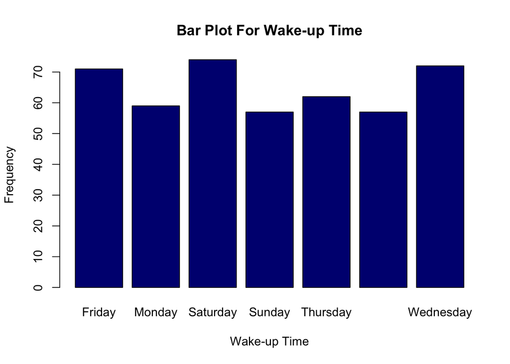

```r
barplot(table(data$w_day_of_week), main = "Bar Plot For Wake-up Time", xlab = "Wake-up Time", ylab = "Frequency", col = "navy")
```

### c. Pie Chart

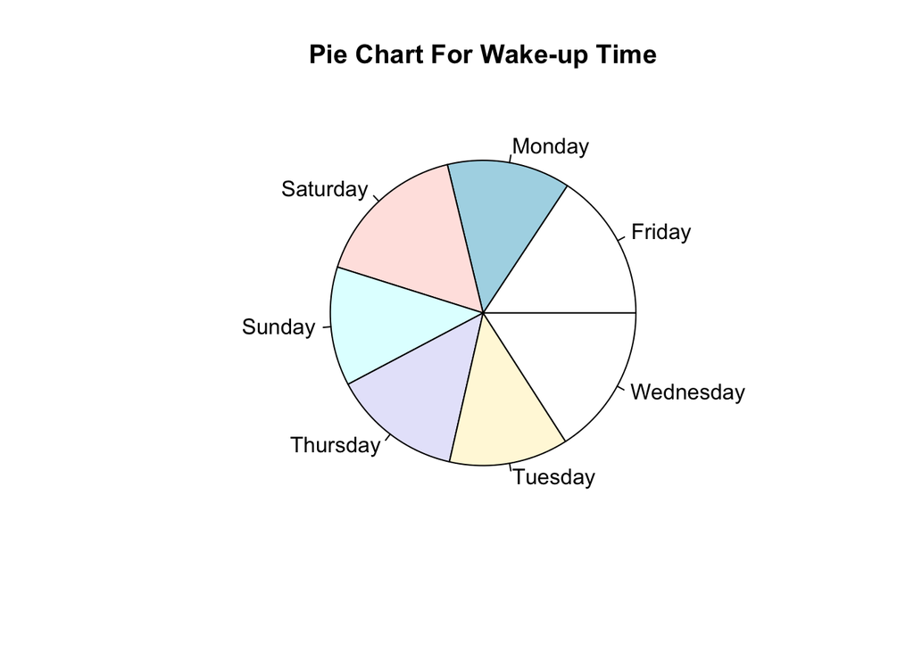

```r
pie(table(data$w_day_of_week), main = "Pie Chart For Wake-up Time")
```

### d. Word Cloud

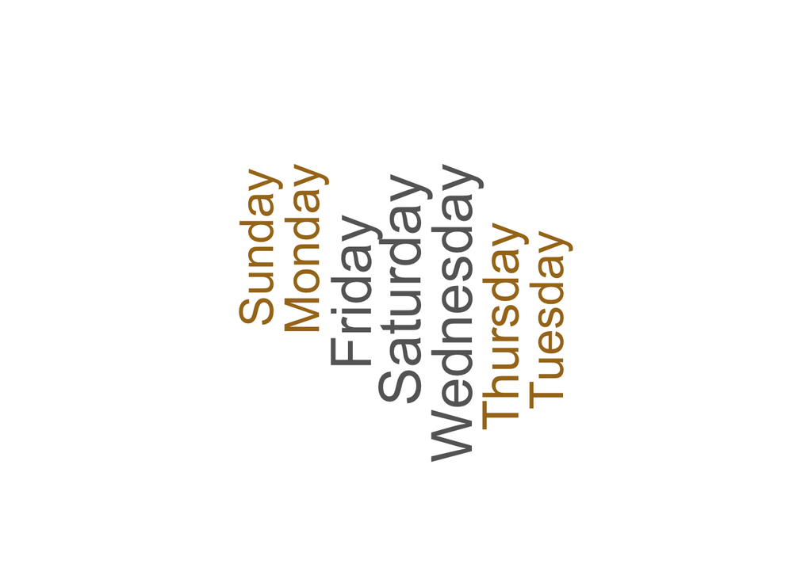

```r
data$w_day_of_week <- as.character(data$w_day_of_week)

time_descriptions <- data$w_day_of_week
words <- unlist(strsplit(time_descriptions, "\\s+"))
word_freqs <- table(words)
word_freq_df <- data.frame(word = names(word_freqs), freq = as.numeric(word_freqs))

if (nrow(word_freq_df) > 0) {
  wordcloud(
    words = word_freq_df$word,
    freq = word_freq_df$freq,
    min.freq = 1,
    scale = c(3, 0.5),
    colors = brewer.pal(8, "Dark2"),
    random.order = FALSE,
    rot.per = 0.8,
    use.r.layout = FALSE
  )
} else {
  cat("Error: No data available for word cloud.\n")
}
```

## 1-3. w_weekend

### a. Frequency Table

```r
freq_table <- summary(factor(data$w_weekend))
freq_table_df <- as.data.frame(freq_table)
print(freq_table_df)
```

```
##   freq_table
## 0        321
## 1        131
```

### b. Bar Plot

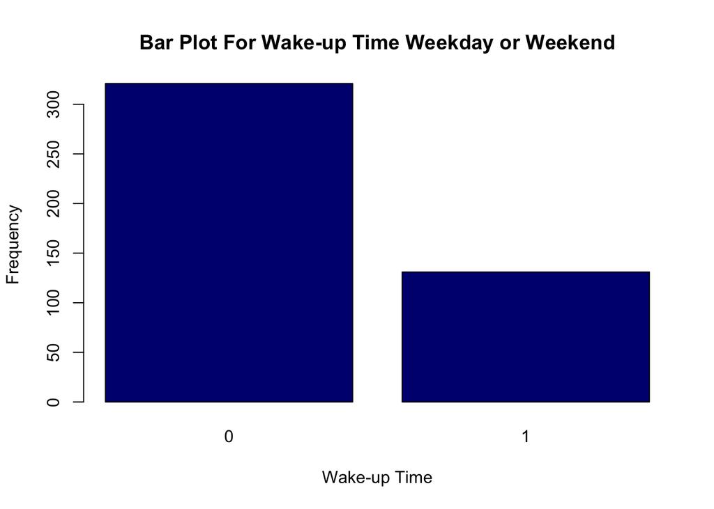

```r
barplot(table(data$w_weekend), main = "Bar Plot For Wake-up Time Weekday or Weekend", xlab = "Wake-up Time", ylab = "Frequency", col = "navy")
```

### c. Pie Chart

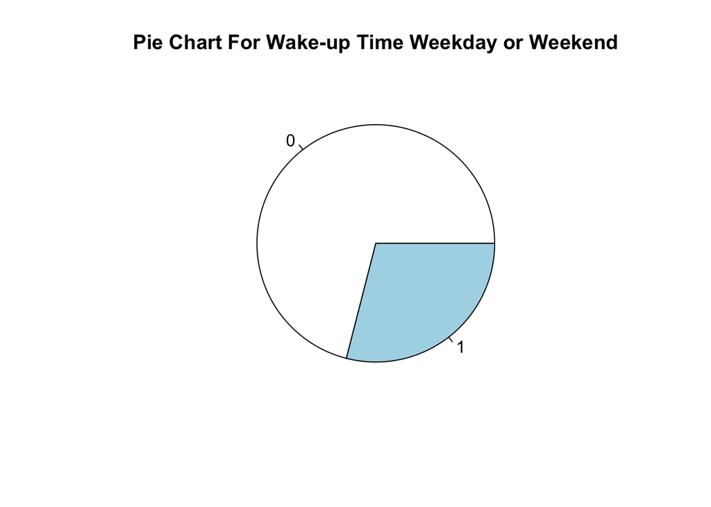

```r
pie(table(data$b_weekend), main = "Pie Chart For Wake-up Time Weekday or Weekend")
```

# Split into Sets

I will split the data into **70%** training, **15%** validation, and **15%** test sets.

```r
set.seed(123)

total_rows <- nrow(data)
indices <- sample(1:total_rows, total_rows)

train_fraction <- 0.7
validation_fraction <- 0.15
test_fraction <- 0.15

train_size <- floor(train_fraction * total_rows)
validation_size <- floor(validation_fraction * total_rows)

train <- data[indices[1:train_size], ]
valid <- data[indices[(train_size + 1):(train_size + validation_size)], ]
test <- data[indices[(train_size + validation_size + 1):total_rows], ]

n_train <- nrow(train)
n_valid <- nrow(valid)
n_test <- nrow(test)

cat("Number of data points in the training set:", n_train, "\n")
```

```
## Number of data points in the training set: 316
```

```r
cat("Number of data points in the validation set:", n_valid, "\n")
```

```
## Number of data points in the validation set: 67
```

```r
cat("Number of data points in the test set:", n_test, "\n")
```

```
## Number of data points in the test set: 69
```

# Classification

## 1. Bedtime

### a. Naive Bayes

#### Considering Bedtime only

```r
library(e1071)
library(nnet)
library(irr)
library(Metrics)
library(pROC)
nb_model <- naiveBayes(Sleep.efficiency.range ~ b_time, data = train)

valid_predictions <- predict(nb_model, newdata = valid)

confusion_matrix <- table(valid_predictions, valid$Sleep.efficiency.range)
accuracy <- sum(diag(confusion_matrix)) / sum(confusion_matrix)
precision <- diag(confusion_matrix) / rowSums(confusion_matrix)
recall <- diag(confusion_matrix) / colSums(confusion_matrix)
f1_score <- 2 * (precision * recall) / (precision + recall)
overall_precision <- mean(precision, na.rm = TRUE)
overall_recall <- mean(recall, na.rm = TRUE)
overall_f1_score <- mean(f1_score, na.rm = TRUE)
kappa <- kappam.fleiss(confusion_matrix)$value

intersection <- sum(diag(confusion_matrix))
union <- sum(confusion_matrix) + sum(confusion_matrix) - sum(diag(confusion_matrix))
jaccard_index <- intersection / union

print(confusion_matrix)
```

```
##
## valid_predictions 0.5~0.59 0.6~0.69 0.7~0.79 0.8~0.89 0.9~0.99
##          0.5~0.59        0        0        1        0        2
##          0.6~0.69        0        1        1        2        0
##          0.7~0.79        0        0        0        0        0
##          0.8~0.89        7        5        5       12        7
##          0.9~0.99        2        1        8        8        5
```

```r
cat("Accuracy on the validation set:", accuracy, "\n")
```

```
## Accuracy on the validation set: 0.2686567
```

```r
cat("Overall Precision on the validation set:", overall_precision, "\n")
```

```
## Overall Precision on the validation set: 0.1979167
```

```r
cat("Overall Recall on the validation set:", overall_recall, "\n")
```

```
## Overall Recall on the validation set: 0.2090909
```

```r
cat("Overall F1-Score on the validation set:", overall_f1_score, "\n")
```

```
## Overall F1-Score on the validation set: 0.2862564
```

```r
cat("Cohen's Kappa on the validation set:", kappa, "\n")
```

```
## Cohen's Kappa on the validation set: 0.1701245
```

```r
cat("Jaccard Index on the validation set:", jaccard_index, "\n")
```

```
## Jaccard Index on the validation set: 0.1551724
```

```r
test_predictions <- predict(nb_model, newdata = test)

confusion_matrix_test <- table(test_predictions, test$Sleep.efficiency.range)
accuracy_test <- sum(diag(confusion_matrix_test)) / sum(confusion_matrix_test)
precision <- diag(confusion_matrix_test) / rowSums(confusion_matrix_test)
recall <- diag(confusion_matrix_test) / colSums(confusion_matrix_test)
f1_score <- 2 * (precision * recall) / (precision + recall)
overall_precision <- mean(precision, na.rm = TRUE)
overall_recall <- mean(recall, na.rm = TRUE)
overall_f1_score <- mean(f1_score, na.rm = TRUE)
kappa <- kappam.fleiss(confusion_matrix_test)$value

intersection <- sum(diag(confusion_matrix_test))
union <- sum(confusion_matrix_test) + sum(confusion_matrix_test) - sum(diag(confusion_matrix_test))
jaccard_index <- intersection / union

print(confusion_matrix_test)
```

```
##
## test_predictions 0.5~0.59 0.6~0.69 0.7~0.79 0.8~0.89 0.9~0.99
##         0.5~0.59        4        0        0        1        1
##         0.6~0.69        0        1        2        0        1
##         0.7~0.79        0        0        0        0        0
##         0.8~0.89        6        3        7       14       14
##         0.9~0.99        0        0        4        4        7
```

```r
cat("Accuracy on the test set:", accuracy_test, "\n")
```

```
## Accuracy on the test set: 0.3768116
```

```r
cat("Overall Precision on the test set:", overall_precision, "\n")
```

```
## Overall Precision on the test set: 0.4253788
```

```r
cat("Overall Recall on the test set:", overall_recall, "\n")
```

```
## Overall Recall on the test set: 0.338238
```

```r
cat("Overall F1-Score on the test set:", overall_f1_score, "\n")
```

```
## Overall F1-Score on the test set: 0.3907164
```

```r
cat("Cohen's Kappa on the test set:", kappa, "\n")
```

```
## Cohen's Kappa on the test set: 0.1185897
```

```r
cat("Jaccard Index on the test set:", jaccard_index, "\n")
```

```
## Jaccard Index on the test set: 0.2321429
```

#### Without Considering Bedtime

```r
nb_model <- naiveBayes(Sleep.efficiency.range ~ Sleep.duration + Deep.sleep.percentage + Light.sleep.percentage + b_weekend + b_day_of_week, data = train)

valid_predictions <- predict(nb_model, newdata = valid)

confusion_matrix <- table(valid_predictions, valid$Sleep.efficiency.range)
accuracy <- sum(diag(confusion_matrix)) / sum(confusion_matrix)
precision <- diag(confusion_matrix) / rowSums(confusion_matrix)
recall <- diag(confusion_matrix) / colSums(confusion_matrix)
f1_score <- 2 * (precision * recall) / (precision + recall)
overall_precision <- mean(precision, na.rm = TRUE)
overall_recall <- mean(recall, na.rm = TRUE)
overall_f1_score <- mean(f1_score, na.rm = TRUE)
kappa <- kappam.fleiss(confusion_matrix)$value

print(confusion_matrix)
```

```
##
## valid_predictions 0.5~0.59 0.6~0.69 0.7~0.79 0.8~0.89 0.9~0.99
##          0.5~0.59        5        5        0        0        0
##          0.6~0.69        4        2        0        0        0
##          0.7~0.79        0        0        0        3        2
##          0.8~0.89        0        0        8       12        7
##          0.9~0.99        0        0        7        7        5
```

```r
cat("Accuracy on the validation set:", accuracy, "\n")
```

```
## Accuracy on the validation set: 0.358209
```

```r
cat("Overall Precision on the validation set:", overall_precision, "\n")
```

```
## Overall Precision on the validation set: 0.3081871
```

```r
cat("Overall Recall on the validation set:", overall_recall, "\n")
```

```
## Overall Recall on the validation set: 0.3487734
```

```r
cat("Overall F1-Score on the validation set:", overall_f1_score, "\n")
```

```
## Overall F1-Score on the validation set: 0.4067086
```

```r
cat("Cohen's Kappa on the validation set:", kappa, "\n")
```

```
## Cohen's Kappa on the validation set: -0.0755814
```

```r
cat("Jaccard Index on the validation set:", jaccard_index, "\n")
```

```
## Jaccard Index on the validation set: 0.2321429
```

```r
test_predictions <- predict(nb_model, newdata = test)

confusion_matrix_test <- table(test_predictions, test$Sleep.efficiency.range)
accuracy_test <- sum(diag(confusion_matrix_test)) / sum(confusion_matrix_test)
precision <- diag(confusion_matrix_test) / rowSums(confusion_matrix_test)
recall <- diag(confusion_matrix_test) / colSums(confusion_matrix_test)
f1_score <- 2 * (precision * recall) / (precision + recall)
overall_precision <- mean(precision, na.rm = TRUE)
overall_recall <- mean(recall, na.rm = TRUE)
overall_f1_score <- mean(f1_score, na.rm = TRUE)
kappa <- kappam.fleiss(confusion_matrix_test)$value

intersection <- sum(diag(confusion_matrix_test))
union <- sum(confusion_matrix_test) + sum(confusion_matrix_test) - sum(diag(confusion_matrix_test))
jaccard_index <- intersection / union

print(confusion_matrix_test)
```

```
##
## test_predictions 0.5~0.59 0.6~0.69 0.7~0.79 0.8~0.89 0.9~0.99
##         0.5~0.59        8        4        0        0        0
##         0.6~0.69        2        0        0        0        0
##         0.7~0.79        0        0        1        3        1
##         0.8~0.89        0        0        7       12       12
##         0.9~0.99        0        0        5        4       10
```

```r
cat("Accuracy on the test set:", accuracy_test, "\n")
```

```
## Accuracy on the test set: 0.4492754
```

```r
cat("Overall Precision on the test set:", overall_precision, "\n")
```

```
## Overall Precision on the test set: 0.3560158
```

```r
cat("Overall Recall on the test set:", overall_recall, "\n")
```

```
## Overall Recall on the test set: 0.3886569
```

```r
cat("Overall F1-Score on the test set:", overall_f1_score, "\n")
```

```
## Overall F1-Score on the test set: 0.4486436
```

```r
cat("Cohen's Kappa on the test set:", kappa, "\n")
```

```
## Cohen's Kappa on the test set: -0.02739726
```

```r
cat("Jaccard Index on the test set:", jaccard_index, "\n")
```

```
## Jaccard Index on the test set: 0.2897196
```

#### Considering Possible Influencial Variables Bedtime

```r
nb_model <- naiveBayes(Sleep.efficiency.range ~ b_time + Sleep.duration + Deep.sleep.percentage + Light.sleep.percentage, data = train)

valid_predictions <- predict(nb_model, newdata = valid)

confusion_matrix <- table(valid_predictions, valid$Sleep.efficiency.range)
accuracy <- sum(diag(confusion_matrix)) / sum(confusion_matrix)
precision <- diag(confusion_matrix) / rowSums(confusion_matrix)
recall <- diag(confusion_matrix) / colSums(confusion_matrix)
f1_score <- 2 * (precision * recall) / (precision + recall)
overall_precision <- mean(precision, na.rm = TRUE)
overall_recall <- mean(recall, na.rm = TRUE)
overall_f1_score <- mean(f1_score, na.rm = TRUE)
kappa <- kappam.fleiss(confusion_matrix)$value

intersection <- sum(diag(confusion_matrix))
union <- sum(confusion_matrix) + sum(confusion_matrix) - sum(diag(confusion_matrix))
jaccard_index <- intersection / union

print(confusion_matrix)
```

```
##
## valid_predictions 0.5~0.59 0.6~0.69 0.7~0.79 0.8~0.89 0.9~0.99
##          0.5~0.59        6        6        0        0        0
##          0.6~0.69        3        1        0        0        0
##          0.7~0.79        0        0        2        2        2
##          0.8~0.89        0        0        6       12        5
##          0.9~0.99        0        0        7        8        7
```

```r
cat("Accuracy on the validation set:", accuracy, "\n")
```

```
## Accuracy on the validation set: 0.4179104
```

```r
cat("Overall Precision on the validation set:", overall_precision, "\n")
```

```
## Overall Precision on the validation set: 0.3846509
```

```r
cat("Overall Recall on the validation set:", overall_recall, "\n")
```

```
## Overall Recall on the validation set: 0.3976623
```

```r
cat("Overall F1-Score on the validation set:", overall_f1_score, "\n")
```

```
## Overall F1-Score on the validation set: 0.373189
```

```r
cat("Cohen's Kappa on the validation set:", kappa, "\n")
```

```
## Cohen's Kappa on the validation set: 0.008810573
```

```r
cat("Jaccard Index on the validation set:", jaccard_index, "\n")
```

```
## Jaccard Index on the validation set: 0.2641509
```

```r
test_predictions <- predict(nb_model, newdata = test)

confusion_matrix_test <- table(test_predictions, test$Sleep.efficiency.range)
accuracy_test <- sum(diag(confusion_matrix_test)) / sum(confusion_matrix_test)
precision <- diag(confusion_matrix_test) / rowSums(confusion_matrix_test)
recall <- diag(confusion_matrix_test) / colSums(confusion_matrix_test)
f1_score <- 2 * (precision * recall) / (precision + recall)
overall_precision <- mean(precision, na.rm = TRUE)
overall_recall <- mean(recall, na.rm = TRUE)
overall_f1_score <- mean(f1_score, na.rm = TRUE)
kappa <- kappam.fleiss(confusion_matrix_test)$value

intersection <- sum(diag(confusion_matrix_test))
union <- sum(confusion_matrix_test) + sum(confusion_matrix_test) - sum(diag(confusion_matrix_test))
jaccard_index <- intersection / union

print(confusion_matrix_test)
```

```
##
## test_predictions 0.5~0.59 0.6~0.69 0.7~0.79 0.8~0.89 0.9~0.99
##         0.5~0.59       10        3        0        0        0
##         0.6~0.69        0        1        0        0        0
##         0.7~0.79        0        0        3        1        0
##         0.8~0.89        0        0        6       12       15
##         0.9~0.99        0        0        4        6        8
```

```r
cat("Accuracy on the test set:", accuracy_test, "\n")
```

```
## Accuracy on the test set: 0.4927536
```

```r
cat("Overall Precision on the test set:", overall_precision, "\n")
```

```
## Overall Precision on the test set: 0.6654623
```

```r
cat("Overall Recall on the test set:", overall_recall, "\n")
```

```
## Overall Recall on the test set: 0.4920349
```

```r
cat("Overall F1-Score on the test set:", overall_f1_score, "\n")
```

```
## Overall F1-Score on the test set: 0.4948578
```

```r
cat("Cohen's Kappa on the test set:", kappa, "\n")
```

```
## Cohen's Kappa on the test set: -0.09223301
```

```r
cat("Jaccard Index on the test set:", jaccard_index, "\n")
```

```
## Jaccard Index on the test set: 0.3269231
```

Comparing the above results, it can be interpreted that although the accuracies are not very high, naive bayes classification performs the best for the case of considering bedtime and all possible influential variables. It has the highest accuracy on both validation set and test set. The small number of data could be the reason for having higher accuracy on test sets than on validation set

### b. Multinomial Logistic Regression

#### Considering Bedtime only

```r
model <- multinom(Sleep.efficiency.range ~ b_time, data = train)
train$Sleep.efficiency.range <- factor(train$Sleep.efficiency.range)
valid$Sleep.efficiency.range <- factor(valid$Sleep.efficiency.range, levels = levels(train$Sleep.efficiency.range))

predicted_classes <- predict(model, newdata = valid, type = "class")
predicted_prob <- predict(model, newdata = valid, type = "probs")
true_labels <- as.numeric(factor(valid$Sleep.efficiency.range))

confusion_matrix <- table(Actual = valid$Sleep.efficiency.range, Predicted = predicted_classes)
accuracy <- sum(diag(confusion_matrix)) / sum(confusion_matrix)
precision <- diag(confusion_matrix) / rowSums(confusion_matrix)
recall <- diag(confusion_matrix) / colSums(confusion_matrix)
f1_score <- 2 * (precision * recall) / (precision + recall)
overall_precision <- mean(precision, na.rm = TRUE)
overall_recall <- mean(recall, na.rm = TRUE)
overall_f1_score <- mean(f1_score, na.rm = TRUE)
kappa <- kappam.fleiss(confusion_matrix)$value
intersection <- sum(diag(confusion_matrix))
union <- sum(confusion_matrix) + sum(confusion_matrix) - sum(diag(confusion_matrix))
jaccard_index <- intersection / union

print(confusion_matrix)
```

```
##           Predicted
## Actual     0.5~0.59 0.6~0.69 0.7~0.79 0.8~0.89 0.9~0.99
##   0.5~0.59        0        0        0        7        2
##   0.6~0.69        0        1        0        5        1
##   0.7~0.79        1        1        0        5        8
##   0.8~0.89        0        2        0       12        8
##   0.9~0.99        2        0        0        7        5
```

```r
cat("Accuracy on the validation set:", accuracy, "\n")
```

```
## Accuracy on the validation set: 0.2686567
```

```r
cat("Overall Precision on the validation set:", overall_precision, "\n")
```

```
## Overall Precision on the validation set: 0.2090909
```

```r
cat("Overall Recall on the validation set:", overall_recall, "\n")
```

```
## Overall Recall on the validation set: 0.1979167
```

```r
cat("Overall F1-Score on the validation set:", overall_f1_score, "\n")
```

```
## Overall F1-Score on the validation set: 0.2862564
```

```r
cat("Cohen's Kappa on the validation set:", kappa, "\n")
```

```
## Cohen's Kappa on the validation set: -0.08921162
```

```r
cat("Jaccard Index on the validation set:", jaccard_index, "\n")
```

```
## Jaccard Index on the validation set: 0.1551724
```

```r
test$Sleep.efficiency.range <- factor(test$Sleep.efficiency.range, levels = levels(train$Sleep.efficiency.range))

predicted_test <- predict(model, newdata = test, type = "probs")
predicted_classes_test <- predict(model, newdata = test, type = "class")
true_labels_test <- as.numeric(factor(test$Sleep.efficiency.range))

confusion_matrix_test <- table(Actual = test$Sleep.efficiency.range, Predicted = predicted_classes_test)

accuracy_test <- sum(diag(confusion_matrix_test)) / sum(confusion_matrix_test)
precision_test <- diag(confusion_matrix_test) / rowSums(confusion_matrix_test)
recall_test <- diag(confusion_matrix_test) / colSums(confusion_matrix_test)
f1_score_test <- 2 * (precision_test * recall_test) / (precision_test + recall_test)
overall_precision_test <- mean(precision_test, na.rm = TRUE)
overall_recall_test <- mean(recall_test, na.rm = TRUE)
overall_f1_score_test <- mean(f1_score_test, na.rm = TRUE)
kappa_test <- kappam.fleiss(confusion_matrix_test)$value
intersection <- sum(diag(confusion_matrix_test))
union <- sum(confusion_matrix_test) + sum(confusion_matrix_test) - sum(diag(confusion_matrix_test))
jaccard_index <- intersection / union

print(confusion_matrix_test)
```

```
##           Predicted
## Actual     0.5~0.59 0.6~0.69 0.7~0.79 0.8~0.89 0.9~0.99
##   0.5~0.59        4        0        0        6        0
##   0.6~0.69        0        1        0        3        0
##   0.7~0.79        0        2        0        7        4
##   0.8~0.89        1        0        0       14        4
##   0.9~0.99        1        1        0       14        7
```

```r
cat("Accuracy on the test set:", accuracy_test, "\n")
```

```
## Accuracy on the test set: 0.3768116
```

```r
cat("Overall Precision on the test set:", overall_precision_test, "\n")
```

```
## Overall Precision on the test set: 0.338238
```

```r
cat("Overall Recall on the test set:", overall_recall_test, "\n")
```

```
## Overall Recall on the test set: 0.4253788
```

```r
cat("Overall F1-Score on the test set:", overall_f1_score_test, "\n")
```

```
## Overall F1-Score on the test set: 0.3907164
```

```r
cat("Cohen's Kappa on the test set:", kappa_test, "\n")
```

```
## Cohen's Kappa on the test set: -0.09508547
```

```r
cat("Jaccard Index on the test set:", jaccard_index, "\n")
```

```
## Jaccard Index on the test set: 0.2321429
```

#### Without Considering Bedtime

```r
model <- multinom(Sleep.efficiency.range ~ Sleep.duration + Deep.sleep.percentage + Light.sleep.percentage, data = train)
train$Sleep.efficiency.range <- factor(train$Sleep.efficiency.range)
valid$Sleep.efficiency.range <- factor(valid$Sleep.efficiency.range, levels = levels(train$Sleep.efficiency.range))

predicted_classes <- predict(model, newdata = valid, type = "class")
predicted_prob <- predict(model, newdata = valid, type = "probs")
true_labels <- as.numeric(factor(valid$Sleep.efficiency.range))

confusion_matrix <- table(Actual = valid$Sleep.efficiency.range, Predicted = predicted_classes)
accuracy <- sum(diag(confusion_matrix)) / sum(confusion_matrix)
precision <- diag(confusion_matrix) / rowSums(confusion_matrix)
recall <- diag(confusion_matrix) / colSums(confusion_matrix)
f1_score <- 2 * (precision * recall) / (precision + recall)
overall_precision <- mean(precision, na.rm = TRUE)
overall_recall <- mean(recall, na.rm = TRUE)
overall_f1_score <- mean(f1_score, na.rm = TRUE)
kappa <- kappam.fleiss(confusion_matrix)$value
intersection <- sum(diag(confusion_matrix))
union <- sum(confusion_matrix) + sum(confusion_matrix) - sum(diag(confusion_matrix))
jaccard_index <- intersection / union

print(confusion_matrix)
```

```
##           Predicted
## Actual     0.5~0.59 0.6~0.69 0.7~0.79 0.8~0.89 0.9~0.99
##   0.5~0.59        4        5        0        0        0
##   0.6~0.69        2        5        0        0        0
##   0.7~0.79        0        0        0        9        6
##   0.8~0.89        0        0        1       16        5
##   0.9~0.99        0        0        0       10        4
```

```r
cat("Accuracy on the validation set:", accuracy, "\n")
```

```
## Accuracy on the validation set: 0.4328358
```

```r
cat("Overall Precision on the validation set:", overall_precision, "\n")
```

```
## Overall Precision on the validation set: 0.4343434
```

```r
cat("Overall Recall on the validation set:", overall_recall, "\n")
```

```
## Overall Recall on the validation set: 0.3780952
```

```r
cat("Overall F1-Score on the validation set:", overall_f1_score, "\n")
```

```
## Overall F1-Score on the validation set: 0.4897086
```

```r
cat("Cohen's Kappa on the validation set:", kappa, "\n")
```

```
## Cohen's Kappa on the validation set: -0.1280488
```

```r
cat("Jaccard Index on the validation set:", jaccard_index, "\n")
```

```
## Jaccard Index on the validation set: 0.2761905
```

```r
test$Sleep.efficiency.range <- factor(test$Sleep.efficiency.range, levels = levels(train$Sleep.efficiency.range))

predicted_test <- predict(model, newdata = test, type = "probs")
predicted_classes_test <- predict(model, newdata = test, type = "class")
true_labels_test <- as.numeric(factor(test$Sleep.efficiency.range))

confusion_matrix_test <- table(Actual = test$Sleep.efficiency.range, Predicted = predicted_classes_test)

accuracy_test <- sum(diag(confusion_matrix_test)) / sum(confusion_matrix_test)
precision_test <- diag(confusion_matrix_test) / rowSums(confusion_matrix_test)
recall_test <- diag(confusion_matrix_test) / colSums(confusion_matrix_test)
f1_score_test <- 2 * (precision_test * recall_test) / (precision_test + recall_test)
overall_precision_test <- mean(precision_test, na.rm = TRUE)
overall_recall_test <- mean(recall_test, na.rm = TRUE)
overall_f1_score_test <- mean(f1_score_test, na.rm = TRUE)
kappa_test <- kappam.fleiss(confusion_matrix_test)$value
intersection <- sum(diag(confusion_matrix_test))
union <- sum(confusion_matrix_test) + sum(confusion_matrix_test) - sum(diag(confusion_matrix_test))
jaccard_index <- intersection / union

print(confusion_matrix_test)
```

```
##           Predicted
## Actual     0.5~0.59 0.6~0.69 0.7~0.79 0.8~0.89 0.9~0.99
##   0.5~0.59        4        6        0        0        0
##   0.6~0.69        3        1        0        0        0
##   0.7~0.79        0        0        0        9        4
##   0.8~0.89        0        0        0       11        8
##   0.9~0.99        0        0        0       16        7
```

```r
cat("Accuracy on the test set:", accuracy_test, "\n")
```

```
## Accuracy on the test set: 0.3333333
```

```r
cat("Overall Precision on the test set:", overall_precision_test, "\n")
```

```
## Overall Precision on the test set: 0.306659
```

```r
cat("Overall Recall on the test set:", overall_recall_test, "\n")
```

```
## Overall Recall on the test set: 0.3470656
```

```r
cat("Overall F1-Score on the test set:", overall_f1_score_test, "\n")
```

```
## Overall F1-Score on the test set: 0.3464349
```

```r
cat("Cohen's Kappa on the test set:", kappa_test, "\n")
```

```
## Cohen's Kappa on the test set: -0.1275773
```

```r
cat("Jaccard Index on the test set:", jaccard_index, "\n")
```

```
## Jaccard Index on the test set: 0.2
```

#### Considering Possible Influencial Variables Bedtime

```r
model <- multinom(Sleep.efficiency.range ~ b_time + Sleep.duration + Deep.sleep.percentage + Light.sleep.percentage, data = train)
train$Sleep.efficiency.range <- factor(train$Sleep.efficiency.range)
valid$Sleep.efficiency.range <- factor(valid$Sleep.efficiency.range, levels = levels(train$Sleep.efficiency.range))

predicted_classes <- predict(model, newdata = valid, type = "class")
predicted_prob <- predict(model, newdata = valid, type = "probs")
true_labels <- as.numeric(factor(valid$Sleep.efficiency.range))

confusion_matrix <- table(Actual = valid$Sleep.efficiency.range, Predicted = predicted_classes)
accuracy <- sum(diag(confusion_matrix)) / sum(confusion_matrix)
precision <- diag(confusion_matrix) / rowSums(confusion_matrix)
recall <- diag(confusion_matrix) / colSums(confusion_matrix)
f1_score <- 2 * (precision * recall) / (precision + recall)
overall_precision <- mean(precision, na.rm = TRUE)
overall_recall <- mean(recall, na.rm = TRUE)
overall_f1_score <- mean(f1_score, na.rm = TRUE)
kappa <- kappam.fleiss(confusion_matrix)$value
intersection <- sum(diag(confusion_matrix))
union <- sum(confusion_matrix) + sum(confusion_matrix) - sum(diag(confusion_matrix))
jaccard_index <- intersection / union

print(confusion_matrix)
```

```
##           Predicted
## Actual     0.5~0.59 0.6~0.69 0.7~0.79 0.8~0.89 0.9~0.99
##   0.5~0.59        5        4        0        0        0
##   0.6~0.69        4        3        0        0        0
##   0.7~0.79        0        0        2        4        9
##   0.8~0.89        0        1        2       10        9
##   0.9~0.99        0        0        3        6        5
```

```r
cat("Accuracy on the validation set:", accuracy, "\n")
```

```
## Accuracy on the validation set: 0.3731343
```

```r
cat("Overall Precision on the validation set:", overall_precision, "\n")
```

```
## Overall Precision on the validation set: 0.3858297
```

```r
cat("Overall Recall on the validation set:", overall_recall, "\n")
```

```
## Overall Recall on the validation set: 0.3867322
```

```r
cat("Overall F1-Score on the validation set:", overall_f1_score, "\n")
```

```
## Overall F1-Score on the validation set: 0.3767669
```

```r
cat("Cohen's Kappa on the validation set:", kappa, "\n")
```

```
## Cohen's Kappa on the validation set: -0.1029412
```

```r
cat("Jaccard Index on the validation set:", jaccard_index, "\n")
```

```
## Jaccard Index on the validation set: 0.2293578
```

```r
test$Sleep.efficiency.range <- factor(test$Sleep.efficiency.range, levels = levels(train$Sleep.efficiency.range))

predicted_test <- predict(model, newdata = test, type = "probs")
predicted_classes_test <- predict(model, newdata = test, type = "class")
true_labels_test <- as.numeric(factor(test$Sleep.efficiency.range))

confusion_matrix_test <- table(Actual = test$Sleep.efficiency.range, Predicted = predicted_classes_test)

accuracy_test <- sum(diag(confusion_matrix_test)) / sum(confusion_matrix_test)
precision_test <- diag(confusion_matrix_test) / rowSums(confusion_matrix_test)
recall_test <- diag(confusion_matrix_test) / colSums(confusion_matrix_test)
f1_score_test <- 2 * (precision_test * recall_test) / (precision_test + recall_test)
overall_precision_test <- mean(precision_test, na.rm = TRUE)
overall_recall_test <- mean(recall_test, na.rm = TRUE)
overall_f1_score_test <- mean(f1_score_test, na.rm = TRUE)
kappa_test <- kappam.fleiss(confusion_matrix_test)$value
intersection <- sum(diag(confusion_matrix_test))
union <- sum(confusion_matrix_test) + sum(confusion_matrix_test) - sum(diag(confusion_matrix_test))
jaccard_index <- intersection / union

print(confusion_matrix_test)
```

```
##           Predicted
## Actual     0.5~0.59 0.6~0.69 0.7~0.79 0.8~0.89 0.9~0.99
##   0.5~0.59        8        2        0        0        0
##   0.6~0.69        3        1        0        0        0
##   0.7~0.79        0        1        1        7        4
##   0.8~0.89        0        0        1       11        7
##   0.9~0.99        0        1        1       12        9
```

```r
cat("Accuracy on the test set:", accuracy_test, "\n")
```

```
## Accuracy on the test set: 0.4347826
```

```r
cat("Overall Precision on the test set:", overall_precision_test, "\n")
```

```
## Overall Precision on the test set: 0.419435
```

```r
cat("Overall Recall on the test set:", overall_recall_test, "\n")
```

```
## Overall Recall on the test set: 0.4154545
```

```r
cat("Overall F1-Score on the test set:", overall_f1_score_test, "\n")
```

```
## Overall F1-Score on the test set: 0.3953422
```

```r
cat("Cohen's Kappa on the test set:", kappa_test, "\n")
```

```
## Cohen's Kappa on the test set: -0.07217573
```

```r
cat("Jaccard Index on the test set:", jaccard_index, "\n")
```

```
## Jaccard Index on the test set: 0.2777778
```

After comparing the above results, I would say that multinomial logistic regression performs the best on the case where bedtime and all possible influential variables are considered. This is because it has the highest accurcy on test set, and it doesn’t have overfitting problems. It is interesting to see that the case where bedtime is not considered has overfitting issue, which mens that its accuracy and other metrics perform better on validation set than on test set.

### c. Random Forest

#### Considering Bedtime only

```r
library(randomForest)
rf_model <- randomForest(as.factor(Sleep.efficiency.range) ~ b_time,
                         data = train,
                         ntree = 100,
                         importance = TRUE)

predicted_classes_rf <- predict(rf_model, newdata = valid)

confusion_matrix_rf <- table(Actual = valid$Sleep.efficiency.range, Predicted = predicted_classes_rf)

accuracy_rf <- sum(diag(confusion_matrix_rf)) / sum(confusion_matrix_rf)
precision_rf <- diag(confusion_matrix_rf) / rowSums(confusion_matrix_rf)
recall_rf <- diag(confusion_matrix_rf) / colSums(confusion_matrix_rf)
f1_score_rf <- 2 * (precision_rf * recall_rf) / (precision_rf + recall_rf)
overall_precision_rf <- mean(precision_rf, na.rm = TRUE)
overall_recall_rf <- mean(recall_rf, na.rm = TRUE)
overall_f1_score_rf <- mean(f1_score_rf, na.rm = TRUE)
kappa <- kappam.fleiss(confusion_matrix_rf)$value

intersection <- sum(diag(confusion_matrix_rf))
union <- sum(confusion_matrix_rf) + sum(confusion_matrix_rf) - sum(diag(confusion_matrix_rf))
jaccard_index <- intersection / union

print(confusion_matrix_rf)
```

```
##           Predicted
## Actual     0.5~0.59 0.6~0.69 0.7~0.79 0.8~0.89 0.9~0.99
##   0.5~0.59        0        0        0        7        2
##   0.6~0.69        0        1        0        5        1
##   0.7~0.79        0        1        1        5        8
##   0.8~0.89        0        2        0       12        8
##   0.9~0.99        0        0        2        7        5
```

```r
cat("Accuracy on the validation set:", accuracy_rf, "\n")
```

```
## Accuracy on the validation set: 0.2835821
```

```r
cat("Overall Precision on the validation set:", overall_precision_rf, "\n")
```

```
## Overall Precision on the validation set: 0.2224242
```

```r
cat("Overall Recall on the validation set:", overall_recall_rf, "\n")
```

```
## Overall Recall on the validation set: 0.28125
```

```r
cat("Overall F1-Score on the validation set:", overall_f1_score_rf, "\n")
```

```
## Overall F1-Score on the validation set: 0.2424701
```

```r
cat("Cohen's Kappa on the validation set:", kappa, "\n")
```

```
## Cohen's Kappa on the validation set: -0.08921162
```

```r
cat("Jaccard Index on the validation set:", jaccard_index, "\n")
```

```
## Jaccard Index on the validation set: 0.1652174
```

```r
print("Variable Importance:")
```

```
## [1] "Variable Importance:"
```

```r
print(importance(rf_model))
```

```
##        0.5~0.59 0.6~0.69  0.7~0.79 0.8~0.89 0.9~0.99 MeanDecreaseAccuracy
## b_time 1.182796 17.24585 -4.599285  12.2858 4.436425             15.19207
##        MeanDecreaseGini
## b_time           21.086
```

```r
predicted_classes_rf_test <- predict(rf_model, newdata = test)

confusion_matrix_rf_test <- table(Actual = test$Sleep.efficiency.range, Predicted = predicted_classes_rf_test)

accuracy_rf_test <- sum(diag(confusion_matrix_rf_test)) / sum(confusion_matrix_rf_test)
precision_rf_test <- diag(confusion_matrix_rf_test) / rowSums(confusion_matrix_rf_test)
recall_rf_test <- diag(confusion_matrix_rf_test) / colSums(confusion_matrix_rf_test)
f1_score_rf_test <- 2 * (precision_rf_test * recall_rf_test) / (precision_rf_test + recall_rf_test)
overall_precision_rf_test <- mean(precision_rf_test, na.rm = TRUE)
overall_recall_rf_test <- mean(recall_rf_test, na.rm = TRUE)
overall_f1_score_rf_test <- mean(f1_score_rf_test, na.rm = TRUE)
kappa_rf_test <- kappam.fleiss(confusion_matrix_rf_test)$value
intersection <- sum(diag(confusion_matrix_rf_test))
union <- sum(confusion_matrix_rf_test) + sum(confusion_matrix_rf_test) - sum(diag(confusion_matrix_rf_test))
jaccard_index <- intersection / union

print(confusion_matrix_rf_test)
```

```
##           Predicted
## Actual     0.5~0.59 0.6~0.69 0.7~0.79 0.8~0.89 0.9~0.99
##   0.5~0.59        0        0        4        6        0
##   0.6~0.69        0        1        0        3        0
##   0.7~0.79        0        2        0        7        4
##   0.8~0.89        0        0        1       14        4
##   0.9~0.99        0        1        1       14        7
```

```r
cat("Accuracy on the test set:", accuracy_rf_test, "\n")
```

```
## Accuracy on the test set: 0.3188406
```

```r
cat("Overall Precision on the test set:", overall_precision_rf_test, "\n")
```

```
## Overall Precision on the test set: 0.258238
```

```r
cat("Overall Recall on the test set:", overall_recall_rf_test, "\n")
```

```
## Overall Recall on the test set: 0.2587121
```

```r
cat("Overall F1-Score on the test set:", overall_f1_score_rf_test, "\n")
```

```
## Overall F1-Score on the test set: 0.3542885
```

```r
cat("Cohen's Kappa on the test set:", kappa_rf_test, "\n")
```

```
## Cohen's Kappa on the test set: -0.09508547
```

```r
cat("Jaccard Index on the test set:", jaccard_index, "\n")
```

```
## Jaccard Index on the test set: 0.1896552
```

#### Without Considering Bedtime

```r
rf_model <- randomForest(as.factor(Sleep.efficiency.range) ~ Sleep.duration + Deep.sleep.percentage + Light.sleep.percentage,
                         data = train,
                         ntree = 100,
                         importance = TRUE)

predicted_classes_rf <- predict(rf_model, newdata = valid)

confusion_matrix_rf <- table(Actual = valid$Sleep.efficiency.range, Predicted = predicted_classes_rf)

accuracy_rf <- sum(diag(confusion_matrix_rf)) / sum(confusion_matrix_rf)
precision_rf <- diag(confusion_matrix_rf) / rowSums(confusion_matrix_rf)
recall_rf <- diag(confusion_matrix_rf) / colSums(confusion_matrix_rf)
f1_score_rf <- 2 * (precision_rf * recall_rf) / (precision_rf + recall_rf)
overall_precision_rf <- mean(precision_rf, na.rm = TRUE)
overall_recall_rf <- mean(recall_rf, na.rm = TRUE)
overall_f1_score_rf <- mean(f1_score_rf, na.rm = TRUE)
kappa <- kappam.fleiss(confusion_matrix_rf)$value

intersection <- sum(diag(confusion_matrix_rf))
union <- sum(confusion_matrix_rf) + sum(confusion_matrix_rf) - sum(diag(confusion_matrix_rf))
jaccard_index <- intersection / union

print(confusion_matrix_rf)
```

```
##           Predicted
## Actual     0.5~0.59 0.6~0.69 0.7~0.79 0.8~0.89 0.9~0.99
##   0.5~0.59        6        3        0        0        0
##   0.6~0.69        2        5        0        0        0
##   0.7~0.79        0        0        4       10        1
##   0.8~0.89        0        1        4       14        3
##   0.9~0.99        0        0        3        6        5
```

```r
cat("Accuracy on the validation set:", accuracy_rf, "\n")
```

```
## Accuracy on the validation set: 0.5074627
```

```r
cat("Overall Precision on the validation set:", overall_precision_rf, "\n")
```

```
## Overall Precision on the validation set: 0.5282251
```

```r
cat("Overall Recall on the validation set:", overall_recall_rf, "\n")
```

```
## Overall Recall on the validation set: 0.5382828
```

```r
cat("Overall F1-Score on the validation set:", overall_f1_score_rf, "\n")
```

```
## Overall F1-Score on the validation set: 0.5223638
```

```r
cat("Cohen's Kappa on the validation set:", kappa, "\n")
```

```
## Cohen's Kappa on the validation set: -0.1029412
```

```r
cat("Jaccard Index on the validation set:", jaccard_index, "\n")
```

```
## Jaccard Index on the validation set: 0.34
```

```r
print("Variable Importance:")
```

```
## [1] "Variable Importance:"
```

```r
print(importance(rf_model))
```

```
##                         0.5~0.59  0.6~0.69  0.7~0.79  0.8~0.89  0.9~0.99
## Sleep.duration         -1.408542 0.1198545 -2.431933 -6.159020 0.8470946
## Deep.sleep.percentage   7.642095 6.6666863  2.018736  9.429666 5.1888456
## Light.sleep.percentage  9.825485 6.5176711  2.608953  5.371591 2.6306521
##                        MeanDecreaseAccuracy MeanDecreaseGini
## Sleep.duration                    -4.527391         25.75647
## Deep.sleep.percentage             11.739129         60.23721
## Light.sleep.percentage             9.565206         56.69060
```

```r
predicted_classes_rf_test <- predict(rf_model, newdata = test)

confusion_matrix_rf_test <- table(Actual = test$Sleep.efficiency.range, Predicted = predicted_classes_rf_test)

accuracy_rf_test <- sum(diag(confusion_matrix_rf_test)) / sum(confusion_matrix_rf_test)
precision_rf_test <- diag(confusion_matrix_rf_test) / rowSums(confusion_matrix_rf_test)
recall_rf_test <- diag(confusion_matrix_rf_test) / colSums(confusion_matrix_rf_test)
f1_score_rf_test <- 2 * (precision_rf_test * recall_rf_test) / (precision_rf_test + recall_rf_test)
overall_precision_rf_test <- mean(precision_rf_test, na.rm = TRUE)
overall_recall_rf_test <- mean(recall_rf_test, na.rm = TRUE)
overall_f1_score_rf_test <- mean(f1_score_rf_test, na.rm = TRUE)
kappa_rf_test <- kappam.fleiss(confusion_matrix_rf_test)$value
intersection <- sum(diag(confusion_matrix_rf_test))
union <- sum(confusion_matrix_rf_test) + sum(confusion_matrix_rf_test) - sum(diag(confusion_matrix_rf_test))
jaccard_index <- intersection / union

print(confusion_matrix_rf_test)
```

```
##           Predicted
## Actual     0.5~0.59 0.6~0.69 0.7~0.79 0.8~0.89 0.9~0.99
##   0.5~0.59        3        7        0        0        0
##   0.6~0.69        1        3        0        0        0
##   0.7~0.79        0        0        4        7        2
##   0.8~0.89        0        0        4       10        5
##   0.9~0.99        0        0        7        9        7
```

```r
cat("Accuracy on the test set:", accuracy_rf_test, "\n")
```

```
## Accuracy on the test set: 0.3913043
```

```r
cat("Overall Precision on the test set:", overall_precision_rf_test, "\n")
```

```
## Overall Precision on the test set: 0.4376712
```

```r
cat("Overall Recall on the test set:", overall_recall_rf_test, "\n")
```

```
## Overall Recall on the test set: 0.4402564
```

```r
cat("Overall F1-Score on the test set:", overall_f1_score_rf_test, "\n")
```

```
## Overall F1-Score on the test set: 0.393136
```

```r
cat("Cohen's Kappa on the test set:", kappa_rf_test, "\n")
```

```
## Cohen's Kappa on the test set: -0.1061947
```

```r
cat("Jaccard Index on the test set:", jaccard_index, "\n")
```

```
## Jaccard Index on the test set: 0.2432432
```

#### Considering Possible Influencial Variables Bedtime

```r
rf_model <- randomForest(as.factor(Sleep.efficiency.range) ~ b_time + Sleep.duration + Deep.sleep.percentage + Light.sleep.percentage,
                         data = train,
                         ntree = 100,
                         importance = TRUE)

predicted_classes_rf <- predict(rf_model, newdata = valid)

confusion_matrix_rf <- table(Actual = valid$Sleep.efficiency.range, Predicted = predicted_classes_rf)

accuracy_rf <- sum(diag(confusion_matrix_rf)) / sum(confusion_matrix_rf)
precision_rf <- diag(confusion_matrix_rf) / rowSums(confusion_matrix_rf)
recall_rf <- diag(confusion_matrix_rf) / colSums(confusion_matrix_rf)
f1_score_rf <- 2 * (precision_rf * recall_rf) / (precision_rf + recall_rf)
overall_precision_rf <- mean(precision_rf, na.rm = TRUE)
overall_recall_rf <- mean(recall_rf, na.rm = TRUE)
overall_f1_score_rf <- mean(f1_score_rf, na.rm = TRUE)
kappa <- kappam.fleiss(confusion_matrix_rf)$value

intersection <- sum(diag(confusion_matrix_rf))
union <- sum(confusion_matrix_rf) + sum(confusion_matrix_rf) - sum(diag(confusion_matrix_rf))
jaccard_index <- intersection / union

print(confusion_matrix_rf)
```

```
##           Predicted
## Actual     0.5~0.59 0.6~0.69 0.7~0.79 0.8~0.89 0.9~0.99
##   0.5~0.59        5        4        0        0        0
##   0.6~0.69        3        4        0        0        0
##   0.7~0.79        0        0        3        6        6
##   0.8~0.89        0        0        6       11        5
##   0.9~0.99        0        0        2        5        7
```

```r
cat("Accuracy on the validation set:", accuracy_rf, "\n")
```

```
## Accuracy on the validation set: 0.4477612
```

```r
cat("Overall Precision on the validation set:", overall_precision_rf, "\n")
```

```
## Overall Precision on the validation set: 0.4653968
```

```r
cat("Overall Recall on the validation set:", overall_recall_rf, "\n")
```

```
## Overall Recall on the validation set: 0.4573232
```

```r
cat("Overall F1-Score on the validation set:", overall_f1_score_rf, "\n")
```

```
## Overall F1-Score on the validation set: 0.4579676
```

```r
cat("Cohen's Kappa on the validation set:", kappa, "\n")
```

```
## Cohen's Kappa on the validation set: -0.1061947
```

```r
cat("Jaccard Index on the validation set:", jaccard_index, "\n")
```

```
## Jaccard Index on the validation set: 0.2884615
```

```r
print("Variable Importance:")
```

```
## [1] "Variable Importance:"
```

```r
print(importance(rf_model))
```

```
##                          0.5~0.59   0.6~0.69 0.7~0.79  0.8~0.89 0.9~0.99
## b_time                  0.6586462  5.6240340 5.932691  3.467765 4.781840
## Sleep.duration         -0.3283421  0.7989959 1.275521 -3.132752 2.982893
## Deep.sleep.percentage   7.7142838  6.9442030 5.293387  8.721868 6.359573
## Light.sleep.percentage  9.5598969 12.3018735 8.189890  6.860342 5.342041
##                        MeanDecreaseAccuracy MeanDecreaseGini
## b_time                            9.0241028         48.67739
## Sleep.duration                    0.1752869         36.75076
## Deep.sleep.percentage            11.3464462         63.25118
## Light.sleep.percentage           14.7265487         69.47573
```

```r
predicted_classes_rf_test <- predict(rf_model, newdata = test)

confusion_matrix_rf_test <- table(Actual = test$Sleep.efficiency.range, Predicted = predicted_classes_rf_test)

accuracy_rf_test <- sum(diag(confusion_matrix_rf_test)) / sum(confusion_matrix_rf_test)
precision_rf_test <- diag(confusion_matrix_rf_test) / rowSums(confusion_matrix_rf_test)
recall_rf_test <- diag(confusion_matrix_rf_test) / colSums(confusion_matrix_rf_test)
f1_score_rf_test <- 2 * (precision_rf_test * recall_rf_test) / (precision_rf_test + recall_rf_test)
overall_precision_rf_test <- mean(precision_rf_test, na.rm = TRUE)
overall_recall_rf_test <- mean(recall_rf_test, na.rm = TRUE)
overall_f1_score_rf_test <- mean(f1_score_rf_test, na.rm = TRUE)
kappa_rf_test <- kappam.fleiss(confusion_matrix_rf_test)$value
intersection <- sum(diag(confusion_matrix_rf_test))
union <- sum(confusion_matrix_rf_test) + sum(confusion_matrix_rf_test) - sum(diag(confusion_matrix_rf_test))
jaccard_index <- intersection / union

print(confusion_matrix_rf_test)
```

```
##           Predicted
## Actual     0.5~0.59 0.6~0.69 0.7~0.79 0.8~0.89 0.9~0.99
##   0.5~0.59        4        6        0        0        0
##   0.6~0.69        1        3        0        0        0
##   0.7~0.79        0        0        5        6        2
##   0.8~0.89        0        0        5        9        5
##   0.9~0.99        0        0        7        9        7
```

```r
cat("Accuracy on the test set:", accuracy_rf_test, "\n")
```

```
## Accuracy on the test set: 0.4057971
```

```r
cat("Overall Precision on the test set:", overall_precision_rf_test, "\n")
```

```
## Overall Precision on the test set: 0.4625295
```

```r
cat("Overall Recall on the test set:", overall_recall_rf_test, "\n")
```

```
## Overall Recall on the test set: 0.4604902
```

```r
cat("Overall F1-Score on the test set:", overall_f1_score_rf_test, "\n")
```

```
## Overall F1-Score on the test set: 0.4250376
```

```r
cat("Cohen's Kappa on the test set:", kappa_rf_test, "\n")
```

```
## Cohen's Kappa on the test set: -0.06907895
```

```r
cat("Jaccard Index on the test set:", jaccard_index, "\n")
```

```
## Jaccard Index on the test set: 0.2545455
```

By looking at the above results, I think random forest performs the best on the case that considers bedtime and all possible influential variables. It doesn’t have overfitting issues and it has the highest accuracy on test set. Interestingly, the case that doesn’t consider bedtime has the highest accuracy on validation set, but the accuracy on test set compared to validation set is quite low, meaning it may have serious overfitting issue.

## 2. Wake-up Time

### a. Naive Bayes

#### Considering Wake-up Time only

```r
nb_model <- naiveBayes(Sleep.efficiency.range ~ w_time, data = train)

valid_predictions <- predict(nb_model, newdata = valid)

confusion_matrix <- table(valid_predictions, valid$Sleep.efficiency.range)
accuracy <- sum(diag(confusion_matrix)) / sum(confusion_matrix)
precision <- diag(confusion_matrix) / rowSums(confusion_matrix)
recall <- diag(confusion_matrix) / colSums(confusion_matrix)
f1_score <- 2 * (precision * recall) / (precision + recall)
overall_precision <- mean(precision, na.rm = TRUE)
overall_recall <- mean(recall, na.rm = TRUE)
overall_f1_score <- mean(f1_score, na.rm = TRUE)
kappa <- kappam.fleiss(confusion_matrix)$value

intersection <- sum(diag(confusion_matrix))
union <- sum(confusion_matrix) + sum(confusion_matrix) - sum(diag(confusion_matrix))
jaccard_index <- intersection / union

print(confusion_matrix)
```

```
##
## valid_predictions 0.5~0.59 0.6~0.69 0.7~0.79 0.8~0.89 0.9~0.99
##          0.5~0.59        0        0        0        0        0
##          0.6~0.69        0        1        2        2        2
##          0.7~0.79        1        0        2        2        0
##          0.8~0.89        6        5        6       10        8
##          0.9~0.99        2        1        5        8        4
```

```r
cat("Accuracy on the validation set:", accuracy, "\n")
```

```
## Accuracy on the validation set: 0.2537313
```

```r
cat("Overall Precision on the validation set:", overall_precision, "\n")
```

```
## Overall Precision on the validation set: 0.2571429
```

```r
cat("Overall Recall on the validation set:", overall_recall, "\n")
```

```
## Overall Recall on the validation set: 0.20329
```

```r
cat("Overall F1-Score on the validation set:", overall_f1_score, "\n")
```

```
## Overall F1-Score on the validation set: 0.2322571
```

```r
cat("Cohen's Kappa on the validation set:", kappa, "\n")
```

```
## Cohen's Kappa on the validation set: 0.1533865
```

```r
cat("Jaccard Index on the validation set:", jaccard_index, "\n")
```

```
## Jaccard Index on the validation set: 0.1452991
```

```r
test_predictions <- predict(nb_model, newdata = test)

confusion_matrix_test <- table(test_predictions, test$Sleep.efficiency.range)
accuracy_test <- sum(diag(confusion_matrix_test)) / sum(confusion_matrix_test)
precision <- diag(confusion_matrix_test) / rowSums(confusion_matrix_test)
recall <- diag(confusion_matrix_test) / colSums(confusion_matrix_test)
f1_score <- 2 * (precision * recall) / (precision + recall)
overall_precision <- mean(precision, na.rm = TRUE)
overall_recall <- mean(recall, na.rm = TRUE)
overall_f1_score <- mean(f1_score, na.rm = TRUE)
kappa <- kappam.fleiss(confusion_matrix_test)$value

intersection <- sum(diag(confusion_matrix_test))
union <- sum(confusion_matrix_test) + sum(confusion_matrix_test) - sum(diag(confusion_matrix_test))
jaccard_index <- intersection / union

print(confusion_matrix_test)
```

```
##
## test_predictions 0.5~0.59 0.6~0.69 0.7~0.79 0.8~0.89 0.9~0.99
##         0.5~0.59        0        0        0        0        0
##         0.6~0.69        4        1        1        3        3
##         0.7~0.79        1        1        0        3        1
##         0.8~0.89        4        2        8        9       12
##         0.9~0.99        1        0        4        4        7
```

```r
cat("Accuracy on the test set:", accuracy_test, "\n")
```

```
## Accuracy on the test set: 0.2463768
```

```r
cat("Overall Precision on the test set:", overall_precision, "\n")
```

```
## Overall Precision on the test set: 0.194494
```

```r
cat("Overall Recall on the test set:", overall_recall, "\n")
```

```
## Overall Recall on the test set: 0.2056064
```

```r
cat("Overall F1-Score on the test set:", overall_f1_score, "\n")
```

```
## Overall F1-Score on the test set: 0.2724359
```

```r
cat("Cohen's Kappa on the test set:", kappa, "\n")
```

```
## Cohen's Kappa on the test set: 0.1666667
```

```r
cat("Jaccard Index on the test set:", jaccard_index, "\n")
```

```
## Jaccard Index on the test set: 0.1404959
```

#### Without Considering Wake-up Time

```r
nb_model <- naiveBayes(Sleep.efficiency.range ~ Sleep.duration + Deep.sleep.percentage + Light.sleep.percentage, data = train)

valid_predictions <- predict(nb_model, newdata = valid)

confusion_matrix <- table(valid_predictions, valid$Sleep.efficiency.range)
accuracy <- sum(diag(confusion_matrix)) / sum(confusion_matrix)
precision <- diag(confusion_matrix) / rowSums(confusion_matrix)
recall <- diag(confusion_matrix) / colSums(confusion_matrix)
f1_score <- 2 * (precision * recall) / (precision + recall)
overall_precision <- mean(precision, na.rm = TRUE)
overall_recall <- mean(recall, na.rm = TRUE)
overall_f1_score <- mean(f1_score, na.rm = TRUE)
kappa <- kappam.fleiss(confusion_matrix)$value

intersection <- sum(diag(confusion_matrix))
union <- sum(confusion_matrix) + sum(confusion_matrix) - sum(diag(confusion_matrix))
jaccard_index <- intersection / union

print(confusion_matrix)
```

```
##
## valid_predictions 0.5~0.59 0.6~0.69 0.7~0.79 0.8~0.89 0.9~0.99
##          0.5~0.59        8        7        0        0        0
##          0.6~0.69        1        0        0        0        0
##          0.7~0.79        0        0        1        2        0
##          0.8~0.89        0        0       11       15        7
##          0.9~0.99        0        0        3        5        7
```

```r
cat("Accuracy on the validation set:", accuracy, "\n")
```

```
## Accuracy on the validation set: 0.4626866
```

```r
cat("Overall Precision on the validation set:", overall_precision, "\n")
```

```
## Overall Precision on the validation set: 0.3575758
```

```r
cat("Overall Recall on the validation set:", overall_recall, "\n")
```

```
## Overall Recall on the validation set: 0.4274747
```

```r
cat("Overall F1-Score on the validation set:", overall_f1_score, "\n")
```

```
## Overall F1-Score on the validation set: 0.4514977
```

```r
cat("Cohen's Kappa on the validation set:", kappa, "\n")
```

```
## Cohen's Kappa on the validation set: -0.09756098
```

```r
cat("Jaccard Index on the validation set:", jaccard_index, "\n")
```

```
## Jaccard Index on the validation set: 0.3009709
```

```r
test_predictions <- predict(nb_model, newdata = test)

confusion_matrix_test <- table(test_predictions, test$Sleep.efficiency.range)
accuracy_test <- sum(diag(confusion_matrix_test)) / sum(confusion_matrix_test)
precision <- diag(confusion_matrix_test) / rowSums(confusion_matrix_test)
recall <- diag(confusion_matrix_test) / colSums(confusion_matrix_test)
f1_score <- 2 * (precision * recall) / (precision + recall)
overall_precision <- mean(precision, na.rm = TRUE)
overall_recall <- mean(recall, na.rm = TRUE)
overall_f1_score <- mean(f1_score, na.rm = TRUE)
kappa <- kappam.fleiss(confusion_matrix_test)$value

intersection <- sum(diag(confusion_matrix_test))
union <- sum(confusion_matrix_test) + sum(confusion_matrix_test) - sum(diag(confusion_matrix_test))
jaccard_index <- intersection / union

print(confusion_matrix_test)
```

```
##
## test_predictions 0.5~0.59 0.6~0.69 0.7~0.79 0.8~0.89 0.9~0.99
##         0.5~0.59        8        4        0        0        0
##         0.6~0.69        2        0        0        0        0
##         0.7~0.79        0        0        1        2        0
##         0.8~0.89        0        0        9       11       12
##         0.9~0.99        0        0        3        6       11
```

```r
cat("Accuracy on the test set:", accuracy_test, "\n")
```

```
## Accuracy on the test set: 0.4492754
```

```r
cat("Overall Precision on the test set:", overall_precision, "\n")
```

```
## Overall Precision on the test set: 0.37875
```

```r
cat("Overall Recall on the test set:", overall_recall, "\n")
```

```
## Overall Recall on the test set: 0.3868263
```

```r
cat("Overall F1-Score on the test set:", overall_f1_score, "\n")
```

```
## Overall F1-Score on the test set: 0.4488183
```

```r
cat("Cohen's Kappa on the test set:", kappa, "\n")
```

```
## Cohen's Kappa on the test set: -0.08695652
```

```r
cat("Jaccard Index on the test set:", jaccard_index, "\n")
```

```
## Jaccard Index on the test set: 0.2897196
```